# Use Loop Function to Create Multiple WordClouds and Conduct Text Comparison of Major Media Houses

#### By Joyce Jiang | Code by Joyce

Declare: My code is adapted from Duong Vu's tutorial on DataCamp "Generating WordClouds in Python", you can check it out at https://www.datacamp.com/community/tutorials/wordcloud-python. There's an unsolved problem in the discussion section of this tutorial. I solved this problem (converting a 3-D shape photo to 2-D to mask it) by using a function to convert the 3-D photo to black and white.

I found this tutorial really intuitive for someone like me who has never done WordClouds before! It does not only have step-by-step instuction but also uses the mask function to show some creative data visualizations. I added some loop function to export wordcloud multiples time for multiple datasets.

Thanks Shaumik for explaining in a digestible way for me to understand fully how WordCloud and stopword work. This script is published for study and research exploration purpose only, and it would not be used for any commercial purpose.

```python
import pandas as pd
from pandas import DataFrame
```

```python
import numpy as np
import pandas as pd
from os import path
#from PIL import Image
from wordcloud import WordCloud, STOPWORDS, ImageColorGenerator

import matplotlib.pyplot as plt
```

```python
#Import interactive graph function

%matplotlib inline
```

```python
df1= pd.read_excel('Output/Facebook_Covid/ChimpReports_Facebook_COVIDPost.xlsx',index=False)
df2= pd.read_excel('Output/Facebook_Covid/Bigeye_Facebook_COVIDPost.xlsx',index=False)
df3= pd.read_excel('Output/Facebook_Covid/Bukedde_Facebook_COVIDPost.xlsx',index=False)
df4= pd.read_excel('Output/Facebook_Covid/Hipipo_Facebook_COVIDPost.xlsx',index=False)
df5= pd.read_excel('Output/Facebook_Covid/Howwebiz_Facebook_COVIDPost.xlsx',index=False)
df6= pd.read_excel('Output/Facebook_Covid/KaowoSports_Facebook_COVIDPost.xlsx',index=False)
df7= pd.read_excel('Output/Facebook_Covid/NBS_Facebook_COVIDPost.xlsx',index=False)
df8= pd.read_excel('Output/Facebook_Covid/NilePost_Facebook_COVIDPost.xlsx',index=False)
df9= pd.read_excel('Output/Facebook_Covid/NTV_Facebook_COVIDPost.xlsx',index=False)
df10= pd.read_excel('Output/Facebook_Covid/PCTech_Facebook_COVIDPost.xlsx',index=False)
df11= pd.read_excel('Output/Facebook_Covid/PMLDaily_Facebook_COVIDPost.xlsx',index=False)
df12= pd.read_excel('Output/Facebook_Covid/RedPepper_Facebook_COVIDPost.xlsx',index=False)
df13= pd.read_excel('Output/Facebook_Covid/SoftPowerNews_Facebook_COVIDPost.xlsx',index=False)
df14= pd.read_excel('Output/Facebook_Covid/Sqoop_Facebook_COVIDPost.xlsx',index=False)
df15= pd.read_excel('Output/Facebook_Covid/TechJaja_Facebook_COVIDPost.xlsx',index=False)
df16= pd.read_excel('Output/Facebook_Covid/TheIndependent_Facebook_COVIDPost.xlsx',index=False)
df17= pd.read_excel('Output/Facebook_Covid/Observer_Facebook_COVIDPost.xlsx',index=False)
df18= pd.read_excel('Output/Facebook_Covid/UgandaRadioNetwork_Facebook_COVIDPost.xlsx',index=False)
df19= pd.read_excel('Output/Facebook_Covid/DailyMonitor_Facebook_COVIDPost.xlsx',index=False)
df20= pd.read_excel('Output/Facebook_Covid/TheNewVision_Facebook_COVIDPost.xlsx',index=False)
```

```python
df1 = df1.rename(columns={'Posted By Username': 'Username'})
df2 = df2.rename(columns={'Posted By Username': 'Username'})
df3 = df3.rename(columns={'Posted By Username': 'Username'})
df4 = df4.rename(columns={'Posted By Username': 'Username'})
df5 = df5.rename(columns={'Posted By Username': 'Username'})
df6 = df6.rename(columns={'Posted By Username': 'Username'})
df7 = df7.rename(columns={'Posted By Username': 'Username'})
df8 = df8.rename(columns={'Posted By Username': 'Username'})
df9 = df9.rename(columns={'Posted By Username': 'Username'})
df10 = df10.rename(columns={'Posted By Username': 'Username'})
df11 = df11.rename(columns={'Posted By Username': 'Username'})
df12 = df12.rename(columns={'Posted By Username': 'Username'})
df13 = df13.rename(columns={'Posted By Username': 'Username'})
df14 = df14.rename(columns={'Posted By Username': 'Username'})
df15 = df15.rename(columns={'Posted By Username': 'Username'})
df16 = df16.rename(columns={'Posted By Username': 'Username'})
df17 = df17.rename(columns={'Posted By Username': 'Username'})
df18 = df18.rename(columns={'Posted By Username': 'Username'})
df19 = df19.rename(columns={'Posted By Username': 'Username'})
df20 = df20.rename(columns={'Posted By Username': 'Username'})
df19.head(2)
```

|  | Unnamed: 0 | Username | Post | Tagged | Link | Link Description | Location | Page Category | Page Likes | Coordinates |
| --- | --- | --- | --- | --- | --- | --- | --- | --- | --- | --- |
| 0 | 0 | Daily Monitor | 4 new COVID-19 cases confirmed from 1,478 samp... | #MonitorUpdates | https://www.facebook.com/DailyMonitor/photos/a... | 4 new COVID-19 cases confirmed from 1,478 samp... | 29-35, 8th Street, Industrial Area, Kampala, 2... | Media/News Company | 1254889 | +00.31628+032.58219/ |
| 1 | 1 | Daily Monitor | Health ministry will start conducting instant ... | #COVID19, #monitortoon, #MonitorUpdates | https://www.facebook.com/DailyMonitor/photos/a... | Health ministry will start conducting instant ... | 29-35, 8th Street, Industrial Area, Kampala, 2... | Media/News Company | 1254889 | +00.31628+032.58219/ |

```python
#Import WordCloud function

?WordCloud
```

```python
#Import gensim for stopwords list

import gensim
from gensim.parsing.preprocessing import STOPWORDS
from nltk.tokenize import word_tokenize

import nltk
nltk.download('punkt')

import re

#all_stopwords = gensim.parsing.preprocessing.STOPWORDS
#print(all_stopwords)
```

### Text cleaning for WordCloud and use a loop function to export all wordcloud graphs. With this you'll be able to compare the frequent words used by different media houses

I applied two stopwords list to the wordcloud because even if after I added some words to the first one, they still showed up in the final wordcloud. There are minor differeces in each format of the word, such as capitialization, containing space and dot, etc.

```
There are 55805 words in the combination of all reviewChimpReports
```

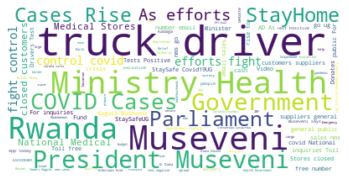

```
There are 11184 words in the combination of all reviewBigEye.ug
```

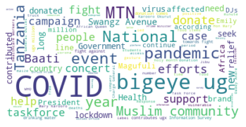

```
There are 15531 words in the combination of all reviewBukedde
```

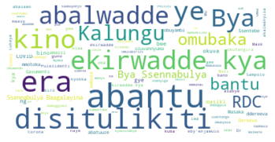

```
There are 10741 words in the combination of all reviewHiPipo
```

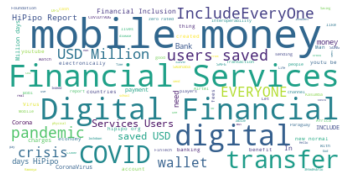

```
There are 2402 words in the combination of all reviewHowwe Biz
```

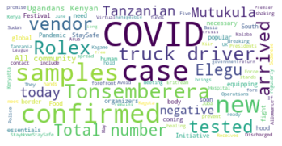

```
There are 6222 words in the combination of all reviewKawowo Sports
```

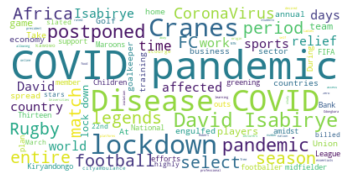

```
There are 67529 words in the combination of all reviewNBS Television
```

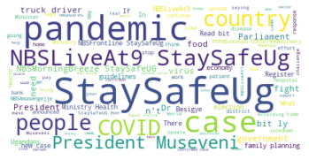

```
There are 57305 words in the combination of all reviewnan
```

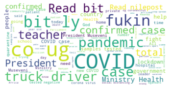

```
There are 29283 words in the combination of all reviewNTV Uganda
```

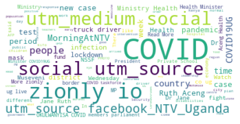

```
There are 3863 words in the combination of all reviewPC Tech Magazine
```

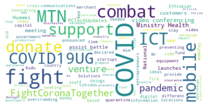

```
There are 68562 words in the combination of all reviewPMLDaily
```

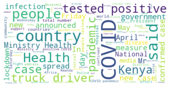

```
There are 85698 words in the combination of all reviewRED Pepper UG
```

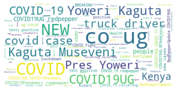

```
There are 89221 words in the combination of all reviewSoftPower News
```

[8 more figures not shown]

```python
#Text cleaning for WordCloud

dfs =[df1,df2,df3,df4,df5,df6,df7,df8,df9,df10,df11,df12,df13,df14,df15,df16,df17,df18,df19,df20]
for df in dfs:

    # Start with one review:
    #text1 = df1.Post[0]
    text = " ".join(post for post in df.Post)
    print ("There are {} words in the combination of all review".format(len(text))+str(df.Username[0]))

    re.sub(r'''(?i)\b((?:https?://|www\d{0,3}[.]|[a-z0-9.\-]+[.][a-z]{2,4}/)(?:[^\s()<>]+|\(([^\s()<>]+|(\([^\s()<>]+\)))*\))+(?:\(([^\s()<>]+|(\([^\s()<>]+\)))*\)|[^\s`!()\[\]{};:'".,<>?«»“”‘’]))''', " ", text)

    all_stopwords_gensim = STOPWORDS.union(set(
        ['https','chimpreport','com', 'COVID19', 'covid','ChimpReportsNews','News','Coronavirus','chimpreports com','By',
         'coronavirus','chimpreports','UgandaNews','Uganda','Featured','chimpreports','uganda','Ugandan','COVID','www',
         'bigeye','bigeye ug','bitly','bit ly','com','co ug','COVID','coronavirus','David Isabirye','Details','nilepost',
         'Details bit','Details','How','https','independent co','It','Live','live','MonitorUpdates','NilePostNews','nilepost','nilepost co',
         'NBSUpdates','NTVNews','ntv','co','Our','Reporter','Our reporter','reporter','PMLDailyNews','redpepper co','redpepper','site','SoftPowerNews','SoftPowerNews',
         'The','softpower ug','story','bit','story nilepost','SqoopUpdates','The','This','THE INDEPENDENT','INDEPENDENT','The Independent','Independent',
         'UPDATE','update','VisionUpdates','words','words www','WWW','www','www.independent','www.softpower','www ugandaradionetwork','We','words','Luganda','ba',
         'bya','eri','ku','nti','ne','nga','mu','omu','wa','co.ug','co  ug','zionly io','zionly.io']))

    #all_stopwords_gensim = STOPWORDS.union(set(
     #   ['https','com','News','www','The','WWW']))

    text_tokens1 = word_tokenize(text)
    tokens_without_sw1 = [word for word in text_tokens1 if not word in all_stopwords_gensim]
    filtered_sentence = (" ").join(tokens_without_sw1)

    # Create stopword list
    stopwords = set(STOPWORDS)
    stopwords.update(['https', 'chimpreport', 'com', 'COVID19', 'covid','ChimpReportsNews','chimpreports','UgandaNews','https','chimpreport','com', 'COVID19', 'covid','ChimpReportsNews','News','Coronavirus','chimpreports com','By',
         'coronavirus','chimpreports','UgandaNews','Uganda','Featured','chimpreports','uganda','Ugandan','COVID','www',
         'bigeye','bigeye.ug','bitly','bit ly','com','co ug','COVID','coronavirus','David Isabirye','Details','nilepost',
         'Details bit','Details','How','https','independent co','It','Live','live','MonitorUpdates','NilePostNews','nilepost','nilepost co',
         'NBSUpdates','NTVNews','ntv','co','Our','Reporter','Our reporter','reporter','PMLDailyNews','redpepper co','redpepper','site','SoftPowerNews','SoftPowerNews',
         'The','softpower ug','story','bit','story nilepost','SqoopUpdates','The','This','THE INDEPENDENT','INDEPENDENT','The Independent','Independent',
         'UPDATE','update','VisionUpdates','words','words www','WWW','www','www.independent','www.softpower','www ugandaradionetwork','We','words','Luganda','ba',
         'bya','eri','ku','nti','ne','nga','mu','omu','wa','co.ug','co  ug','zionly io'])

    # Create and generate a word cloud image:
    wordcloud = WordCloud(max_font_size=50, max_words=100, background_color="white",stopwords=stopwords).generate(filtered_sentence)

    # Display the generated image:
    plt.imshow(wordcloud, interpolation='bilinear')
    plt.axis("off")
    plt.show()
    #plt.savefig()
    wordcloud.to_file("Output/WordCloud/FB_Covid/"+str(df.Username[0])+"_Facebook_COVIDPost.png")
```

### Defined a function wordcloud_create()

```python
def wordcloud_create(column):
    text = " ".join(post for post in column)
    print ("There are {} words in the combination of all review".format(len(text)))
    re.sub(r'''(?i)\b((?:https?://|www\d{0,3}[.]|[a-z0-9.\-]+[.][a-z]{2,4}/)(?:[^\s()<>]+|\(([^\s()<>]+|(\([^\s()<>]+\)))*\))+(?:\(([^\s()<>]+|(\([^\s()<>]+\)))*\)|[^\s`!()\[\]{};:'".,<>?«»“”‘’]))''', " ", text)

#all_stopwords_gensim = STOPWORDS.union(set(
#    ['https','chimpreport','com', 'COVID19', 'covid','ChimpReportsNews','News','Coronavirus','chimpreports com','By','coronavirus','chimpreports','UgandaNews','Uganda','Featured','chimpreports','uganda','Ugandan','COVID','www','bigeye','bigeye ug','bitly','bit ly','com','co ug','COVID','coronavirus','David Isabirye','Details','nilepost',
 #    'Details bit','Details','How','https','independent co','It','Live','live','MonitorUpdates','NilePostNews','nilepost','nilepost co',
  #   'NBSUpdates','NTVNews','ntv','co','Our','Reporter','Our reporter','reporter','PMLDailyNews','redpepper co','redpepper','site','SoftPowerNews','SoftPowerNews',
   #  'The','softpower ug','story','bit','story nilepost','SqoopUpdates','The','This','THE INDEPENDENT','INDEPENDENT','The Independent','Independent',
    # 'UPDATE','update','VisionUpdates','words','words www','WWW','www','www.independent','www.softpower','www ugandaradionetwork','We','words','Luganda','ba',
     #'bya','eri','ku','nti','ne','nga','mu','omu','wa','co.ug','co  ug','zionly io','zionly.io','softpower.ug','www\softpower','ug']))
    all_stopwords_gensim = STOPWORDS.union(set(['https','com','News','www','The','WWW']))
    text_tokens1 = word_tokenize(text)
    tokens_without_sw1 = [word for word in text_tokens1 if not word in all_stopwords_gensim]
    filtered_sentence = (" ").join(tokens_without_sw1)

    # Create stopword list
#stopwords = set(STOPWORDS)
#stopwords.update(['https','chimpreport','com', 'COVID19', 'covid','ChimpReportsNews','News','Coronavirus','chimpreports com','By','coronavirus','chimpreports','UgandaNews','Uganda','Featured','chimpreports','uganda','Ugandan','COVID','www','bigeye','bigeye ug','bitly','bit ly','com','co ug','COVID','coronavirus','David Isabirye','Details','nilepost',
 #    'Details bit','Details','How','https','independent co','It','Live','live','MonitorUpdates','NilePostNews','nilepost','nilepost co',
  #   'NBSUpdates','NTVNews','ntv','co','Our','Reporter','Our reporter','reporter','PMLDailyNews','redpepper co','redpepper','site','SoftPowerNews','SoftPowerNews',
   #  'The','softpower ug','story','bit','story nilepost','SqoopUpdates','The','This','THE INDEPENDENT','INDEPENDENT','The Independent','Independent',
    # 'UPDATE','update','VisionUpdates','words','words www','WWW','www','www.independent','www.softpower','www ugandaradionetwork','We','words','Luganda','ba',
     #'bya','eri','ku','nti','ne','nga','mu','omu','wa','co.ug','co  ug','zionly io','zionly.io','softpower.ug','www/softpower','ug','http'])

    # Create and generate a word cloud image:
    wordcloud = WordCloud(max_font_size=50, max_words=100, background_color="white",stopwords=stopwords).generate(filtered_sentence)

    # Display the generated image:
    plt.imshow(wordcloud, interpolation='bilinear')
    plt.axis("off")
    plt.show()

    #plt.savefig()
#    name=input("Name of the file")
#    wordcloud.to_file("Output/WordCloud/FB_BW/BW_YouTube_BWChannel.png")
#    wordcloud.to_file("Output/WordCloud/M7_"+str(name)+"_YouTube_Comment.png")
```

```python
M71= pd.read_excel('Output/Youtube_Comment/M7Address_Youtube1.xlsx',index=False)
M72= pd.read_excel('Output/Youtube_Comment/M7Address_Youtube2.xlsx',index=False)
M73= pd.read_excel('Output/Youtube_Comment/M7Address_Youtube3.xlsx',index=False)
M74= pd.read_excel('Output/Youtube_Comment/M7Address_Youtube4.xlsx',index=False)
EC= pd.read_excel('Output/Youtube_Comment/EricOmondi _Youtube.xlsx',index=False)
```

### Apply wordcloud_create()

```
There are 5120 words in the combination of all review
```

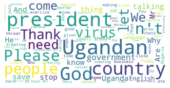

```python
 wordcloud_create(M71.Comment)
```

```
There are 6665 words in the combination of all review
```

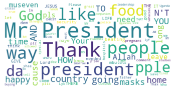

```python
wordcloud_create(M72.Comment)
```

```
There are 12160 words in the combination of all review
```

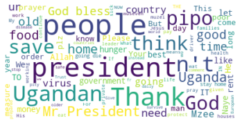

```python
wordcloud_create(M73.Comment)
```

```
There are 5578 words in the combination of all review
```

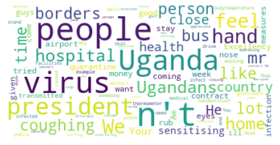

```python
wordcloud_create(M74.Comment)
```

```
There are 23512 words in the combination of all review
```

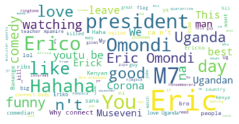

```python
wordcloud_create(EC.Comment)
```

# Visualization

Notice: the content is not important here

```python
from PIL import Image

#mask = np.array(Image.open("img/wine.png"))
#mask
```

### Mask a 3-D graph to a list of vector

```python
mask = np.array(Image.open("img/Covid.png"))
mask
```

[output not shown]

### *Important step: reshape a 3-D graph to a 2-D one by using rgb2gray (convert it to a black and white graph)

```python
#mask = mask.reshape((wine_mask.shape[0],-1), order='F')
from skimage.color import rgb2gray
grey_mask=rgb2gray(mask)
grey_mask
```

```
array([[0., 0., 0., ..., 0., 0., 0.],
       [0., 0., 0., ..., 0., 0., 0.],
       [0., 0., 0., ..., 0., 0., 0.],
       ...,
       [0., 0., 0., ..., 0., 0., 0.],
       [0., 0., 0., ..., 0., 0., 0.],
       [0., 0., 0., ..., 0., 0., 0.]])
```

```python
def transform_format(val):
    if val == 0:
        return 255
    else:
        return val
```

```python
#transformed_mask = np.ndarray((mask.shape[0],mask.shape[1]), np.int32)
transformed_mask = np.ndarray((grey_mask.shape[0],grey_mask.shape[1]), np.int32)

for i in range(len(grey_mask)):
    transformed_mask[i] = list(map(transform_format, grey_mask[i]))
```

```python
transformed_mask
```

```
array([[255, 255, 255, ..., 255, 255, 255],
       [255, 255, 255, ..., 255, 255, 255],
       [255, 255, 255, ..., 255, 255, 255],
       ...,
       [255, 255, 255, ..., 255, 255, 255],
       [255, 255, 255, ..., 255, 255, 255],
       [255, 255, 255, ..., 255, 255, 255]])
```

```
There are 12160 words in the combination of all review
```

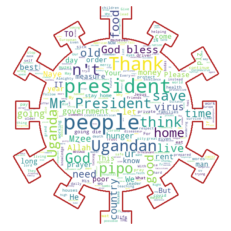

```
<wordcloud.wordcloud.WordCloud at 0x1e5fad1ce48>
```

```python
text = " ".join(post for post in M73.Comment)
print ("There are {} words in the combination of all review".format(len(text)))

re.sub(r'''(?i)\b((?:https?://|www\d{0,3}[.]|[a-z0-9.\-]+[.][a-z]{2,4}/)(?:[^\s()<>]+|\(([^\s()<>]+|(\([^\s()<>]+\)))*\))+(?:\(([^\s()<>]+|(\([^\s()<>]+\)))*\)|[^\s`!()\[\]{};:'".,<>?«»“”‘’]))''', " ", text)

#all_stopwords_gensim = STOPWORDS.union(set(
#    ['https','chimpreport','com', 'COVID19', 'covid','ChimpReportsNews','News','Coronavirus','chimpreports com','By','coronavirus','chimpreports','UgandaNews','Uganda','Featured','chimpreports','uganda','Ugandan','COVID','www','bigeye','bigeye ug','bitly','bit ly','com','co ug','COVID','coronavirus','David Isabirye','Details','nilepost',
 #    'Details bit','Details','How','https','independent co','It','Live','live','MonitorUpdates','NilePostNews','nilepost','nilepost co',
  #   'NBSUpdates','NTVNews','ntv','co','Our','Reporter','Our reporter','reporter','PMLDailyNews','redpepper co','redpepper','site','SoftPowerNews','SoftPowerNews',
   #  'The','softpower ug','story','bit','story nilepost','SqoopUpdates','The','This','THE INDEPENDENT','INDEPENDENT','The Independent','Independent',
    # 'UPDATE','update','VisionUpdates','words','words www','WWW','www','www.independent','www.softpower','www ugandaradionetwork','We','words','Luganda','ba',
     #'bya','eri','ku','nti','ne','nga','mu','omu','wa','co.ug','co  ug','zionly io','zionly.io','softpower.ug','www\softpower','ug']))

all_stopwords_gensim = STOPWORDS.union(set(['https','com','News','www','The','WWW']))

text_tokens1 = word_tokenize(text)
tokens_without_sw1 = [word for word in text_tokens1 if not word in all_stopwords_gensim]
filtered_sentence = (" ").join(tokens_without_sw1)

    # Create stopword list
#stopwords = set(STOPWORDS)
#stopwords.update(['https','chimpreport','com', 'COVID19', 'covid','ChimpReportsNews','News','Coronavirus','chimpreports com','By','coronavirus','chimpreports','UgandaNews','Uganda','Featured','chimpreports','uganda','Ugandan','COVID','www','bigeye','bigeye ug','bitly','bit ly','com','co ug','COVID','coronavirus','David Isabirye','Details','nilepost',
 #    'Details bit','Details','How','https','independent co','It','Live','live','MonitorUpdates','NilePostNews','nilepost','nilepost co',
  #   'NBSUpdates','NTVNews','ntv','co','Our','Reporter','Our reporter','reporter','PMLDailyNews','redpepper co','redpepper','site','SoftPowerNews','SoftPowerNews',
   #  'The','softpower ug','story','bit','story nilepost','SqoopUpdates','The','This','THE INDEPENDENT','INDEPENDENT','The Independent','Independent',
    # 'UPDATE','update','VisionUpdates','words','words www','WWW','www','www.independent','www.softpower','www ugandaradionetwork','We','words','Luganda','ba',
     #'bya','eri','ku','nti','ne','nga','mu','omu','wa','co.ug','co  ug','zionly io','zionly.io','softpower.ug','www/softpower','ug','http'])

    # Create and generate a word cloud image:
wordcloud = WordCloud(max_font_size=50, max_words=300, background_color="white", mask=transformed_mask,contour_color='firebrick',contour_width=3).generate(filtered_sentence)

    # Display the generated image:
plt.imshow(wordcloud, interpolation='bilinear')
plt.axis("off")
plt.show()
    #plt.savefig()
wordcloud.to_file("Output/WordCloud/explore1.png")
#name=input("Name of the file")
```

### Adjust max_word to get a different visualized result

Mask a Ugandan national flag to the wordcloud

```
There are 12160 words in the combination of all review
```

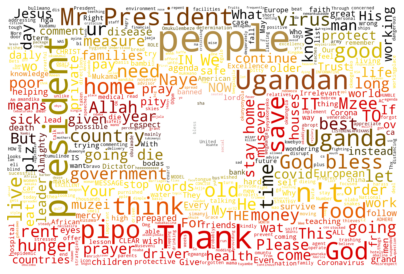

```
<wordcloud.wordcloud.WordCloud at 0x1e5fad6fb08>
```

```python
# Generate a word cloud image
mask = np.array(Image.open("img/uganda.png"))



text = " ".join(post for post in M73.Comment)
print ("There are {} words in the combination of all review".format(len(text)))

re.sub(r'''(?i)\b((?:https?://|www\d{0,3}[.]|[a-z0-9.\-]+[.][a-z]{2,4}/)(?:[^\s()<>]+|\(([^\s()<>]+|(\([^\s()<>]+\)))*\))+(?:\(([^\s()<>]+|(\([^\s()<>]+\)))*\)|[^\s`!()\[\]{};:'".,<>?«»“”‘’]))''', " ", text)

#all_stopwords_gensim = STOPWORDS.union(set(
#    ['https','chimpreport','com', 'COVID19', 'covid','ChimpReportsNews','News','Coronavirus','chimpreports com','By','coronavirus','chimpreports','UgandaNews','Uganda','Featured','chimpreports','uganda','Ugandan','COVID','www','bigeye','bigeye ug','bitly','bit ly','com','co ug','COVID','coronavirus','David Isabirye','Details','nilepost',
 #    'Details bit','Details','How','https','independent co','It','Live','live','MonitorUpdates','NilePostNews','nilepost','nilepost co',
  #   'NBSUpdates','NTVNews','ntv','co','Our','Reporter','Our reporter','reporter','PMLDailyNews','redpepper co','redpepper','site','SoftPowerNews','SoftPowerNews',
   #  'The','softpower ug','story','bit','story nilepost','SqoopUpdates','The','This','THE INDEPENDENT','INDEPENDENT','The Independent','Independent',
    # 'UPDATE','update','VisionUpdates','words','words www','WWW','www','www.independent','www.softpower','www ugandaradionetwork','We','words','Luganda','ba',
     #'bya','eri','ku','nti','ne','nga','mu','omu','wa','co.ug','co  ug','zionly io','zionly.io','softpower.ug','www\softpower','ug']))

all_stopwords_gensim = STOPWORDS.union(set(['https','com','News','www','The','WWW']))

text_tokens1 = word_tokenize(text)
tokens_without_sw1 = [word for word in text_tokens1 if not word in all_stopwords_gensim]
filtered_sentence = (" ").join(tokens_without_sw1)

    # Create stopword list
#stopwords = set(STOPWORDS)
#stopwords.update(['https','chimpreport','com', 'COVID19', 'covid','ChimpReportsNews','News','Coronavirus','chimpreports com','By','coronavirus','chimpreports','UgandaNews','Uganda','Featured','chimpreports','uganda','Ugandan','COVID','www','bigeye','bigeye ug','bitly','bit ly','com','co ug','COVID','coronavirus','David Isabirye','Details','nilepost',
 #    'Details bit','Details','How','https','independent co','It','Live','live','MonitorUpdates','NilePostNews','nilepost','nilepost co',
  #   'NBSUpdates','NTVNews','ntv','co','Our','Reporter','Our reporter','reporter','PMLDailyNews','redpepper co','redpepper','site','SoftPowerNews','SoftPowerNews',
   #  'The','softpower ug','story','bit','story nilepost','SqoopUpdates','The','This','THE INDEPENDENT','INDEPENDENT','The Independent','Independent',
    # 'UPDATE','update','VisionUpdates','words','words www','WWW','www','www.independent','www.softpower','www ugandaradionetwork','We','words','Luganda','ba',
     #'bya','eri','ku','nti','ne','nga','mu','omu','wa','co.ug','co  ug','zionly io','zionly.io','softpower.ug','www/softpower','ug','http'])

    # Create and generate a word cloud image:
wordcloud = WordCloud(max_words=500, background_color="white", mask=mask,mode="RGBA").generate(filtered_sentence)


#wordcloud_fra = WordCloud(background_color="white", mode="RGBA", max_words=1000, mask=mask).generate(fra)

# create coloring from image
image_colors = ImageColorGenerator(mask)
plt.figure(figsize=[7,7])
plt.imshow(wordcloud.recolor(color_func=image_colors), interpolation="bilinear")
plt.axis("off")

# store to file
#plt.savefig("img/fra_wine.png", format="png")

plt.show()
wordcloud.to_file("Output/WordCloud/explore2.png")
```

```python
df3= pd.read_excel('Output/Facebook_Covid/Bukedde_Facebook_COVIDPost.xlsx',index=False)
```

### Mask Castro to the wordcloud (set max_word to a large number to get a vivid sample)

```
There are 15531 words in the combination of all review
```

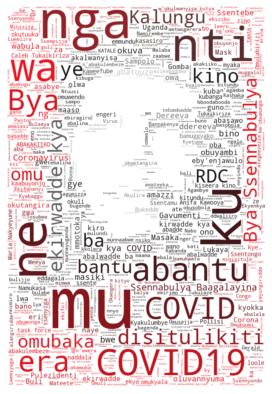

```
<wordcloud.wordcloud.WordCloud at 0x1b20fad0248>
```

```python
# Generate a word cloud image
mask = np.array(Image.open("img/Castro.jpg"))



text = " ".join(post for post in df3.Post)
print ("There are {} words in the combination of all review".format(len(text)))

re.sub(r'''(?i)\b((?:https?://|www\d{0,3}[.]|[a-z0-9.\-]+[.][a-z]{2,4}/)(?:[^\s()<>]+|\(([^\s()<>]+|(\([^\s()<>]+\)))*\))+(?:\(([^\s()<>]+|(\([^\s()<>]+\)))*\)|[^\s`!()\[\]{};:'".,<>?«»“”‘’]))''', " ", text)

#all_stopwords_gensim = STOPWORDS.union(set(
#    ['https','chimpreport','com', 'COVID19', 'covid','ChimpReportsNews','News','Coronavirus','chimpreports com','By','coronavirus','chimpreports','UgandaNews','Uganda','Featured','chimpreports','uganda','Ugandan','COVID','www','bigeye','bigeye ug','bitly','bit ly','com','co ug','COVID','coronavirus','David Isabirye','Details','nilepost',
 #    'Details bit','Details','How','https','independent co','It','Live','live','MonitorUpdates','NilePostNews','nilepost','nilepost co',
  #   'NBSUpdates','NTVNews','ntv','co','Our','Reporter','Our reporter','reporter','PMLDailyNews','redpepper co','redpepper','site','SoftPowerNews','SoftPowerNews',
   #  'The','softpower ug','story','bit','story nilepost','SqoopUpdates','The','This','THE INDEPENDENT','INDEPENDENT','The Independent','Independent',
    # 'UPDATE','update','VisionUpdates','words','words www','WWW','www','www.independent','www.softpower','www ugandaradionetwork','We','words','Luganda','ba',
     #'bya','eri','ku','nti','ne','nga','mu','omu','wa','co.ug','co  ug','zionly io','zionly.io','softpower.ug','www\softpower','ug']))

all_stopwords_gensim = STOPWORDS.union(set(['https','com','News','www','The','WWW']))

text_tokens1 = word_tokenize(text)
tokens_without_sw1 = [word for word in text_tokens1 if not word in all_stopwords_gensim]
filtered_sentence = (" ").join(tokens_without_sw1)

    # Create stopword list
#stopwords = set(STOPWORDS)
#stopwords.update(['https','chimpreport','com', 'COVID19', 'covid','ChimpReportsNews','News','Coronavirus','chimpreports com','By','coronavirus','chimpreports','UgandaNews','Uganda','Featured','chimpreports','uganda','Ugandan','COVID','www','bigeye','bigeye ug','bitly','bit ly','com','co ug','COVID','coronavirus','David Isabirye','Details','nilepost',
 #    'Details bit','Details','How','https','independent co','It','Live','live','MonitorUpdates','NilePostNews','nilepost','nilepost co',
  #   'NBSUpdates','NTVNews','ntv','co','Our','Reporter','Our reporter','reporter','PMLDailyNews','redpepper co','redpepper','site','SoftPowerNews','SoftPowerNews',
   #  'The','softpower ug','story','bit','story nilepost','SqoopUpdates','The','This','THE INDEPENDENT','INDEPENDENT','The Independent','Independent',
    # 'UPDATE','update','VisionUpdates','words','words www','WWW','www','www.independent','www.softpower','www ugandaradionetwork','We','words','Luganda','ba',
     #'bya','eri','ku','nti','ne','nga','mu','omu','wa','co.ug','co  ug','zionly io','zionly.io','softpower.ug','www/softpower','ug','http'])

    # Create and generate a word cloud image:
wordcloud = WordCloud(max_words=800, background_color="white", mask=mask,mode="RGBA").generate(filtered_sentence)


#wordcloud_fra = WordCloud(background_color="white", mode="RGBA", max_words=1000, mask=mask).generate(fra)

# create coloring from image
image_colors = ImageColorGenerator(mask)
plt.figure(figsize=[7,7])
plt.imshow(wordcloud.recolor(color_func=image_colors), interpolation="bilinear")
plt.axis("off")

# store to file
#plt.savefig("img/fra_wine.png", format="png")

plt.show()
wordcloud.to_file("Output/WordCloud/explore3.png")
```